# Uso de API de Covid19 con Pandas

https://covid19api.com/

https://api.covid19api.com/

# Instalación pandas

Para comenzar instalamos los pandas para poder importar la libreria con los datos que vamos a utilizar

```python
!pip install pandas
```

# Configuración

Una vez instalado, porcedemos a importar la libreria para poder comenzar a usar los datos

```python
import pandas as pd
```

# Variables

A través de la URL, seleccionamos la variables con las que vamos a trabajar, en este caso los países

```python
url = 'https://api.covid19api.com/countries'
```

```python
url
```

```
'https://api.covid19api.com/countries'
```

## Creación de *Dataframes*

Utilizamos la función `read_json` para leer los datos JSON de la API:

Una vez leemos los datos, creamos un dataframe, es decie, una tabla de datos para explorarla posteriormente

```python
df = pd.read_json(url)
```

```python
df
```

|  | Country | Slug | ISO2 |
| --- | --- | --- | --- |
| 0 | Martinique | martinique | MQ |
| 1 | Uruguay | uruguay | UY |
| 2 | Kazakhstan | kazakhstan | KZ |
| 3 | Lebanon | lebanon | LB |
| 4 | Morocco | morocco | MA |
| ... | ... | ... | ... |
| 243 | Dominican Republic | dominican-republic | DO |
| 244 | Liberia | liberia | LR |
| 245 | Monaco | monaco | MC |
| 246 | Nigeria | nigeria | NG |
| 247 | Paraguay | paraguay | PY |

248 rows × 3 columns

# Explorar tabla

- Cabecera
- Cola
- Descripción

Aquí comenzamos el proceso de exploracion de la cabecera, cola y descripción de la tabla, datos que porteriormente utilizaremos para nuestras gráficas.

```python
df.head()
```

|  | Country | Slug | ISO2 |
| --- | --- | --- | --- |
| 0 | Martinique | martinique | MQ |
| 1 | Uruguay | uruguay | UY |
| 2 | Kazakhstan | kazakhstan | KZ |
| 3 | Lebanon | lebanon | LB |
| 4 | Morocco | morocco | MA |

```python
df.tail()
```

|  | Country | Slug | ISO2 |
| --- | --- | --- | --- |
| 243 | Dominican Republic | dominican-republic | DO |
| 244 | Liberia | liberia | LR |
| 245 | Monaco | monaco | MC |
| 246 | Nigeria | nigeria | NG |
| 247 | Paraguay | paraguay | PY |

```python
df.describe()
```

|  | Country | Slug | ISO2 |
| --- | --- | --- | --- |
| count | 248 | 248 | 248 |
| unique | 248 | 248 | 248 |
| top | Mexico | australia | NP |
| freq | 1 | 1 | 1 |

```python
df.info()
```

```
<class 'pandas.core.frame.DataFrame'>
RangeIndex: 248 entries, 0 to 247
Data columns (total 3 columns):
 #   Column   Non-Null Count  Dtype
---  ------   --------------  -----
 0   Country  248 non-null    object
 1   Slug     248 non-null    object
 2   ISO2     248 non-null    object
dtypes: object(3)
memory usage: 5.9+ KB
```

# Acceso a datos

```python
df['Country']
```

```
0              Martinique
1                 Uruguay
2              Kazakhstan
3                 Lebanon
4                 Morocco
              ...
243    Dominican Republic
244               Liberia
245                Monaco
246               Nigeria
247              Paraguay
Name: Country, Length: 248, dtype: object
```

```python
df['Country'][2]
```

```
'Kazakhstan'
```

# Tiempo real

Aqui usaremos la URL del país seleccionado, en este caso España, para aportar los datos a tiempo real, tanto los casos confirmados como la fecha de estos. Podemos verlos de manera individual en las distintas dataframes y por último visualizarlo en formato gráfico, donde vemos representados los datos de la tabla.

```python
url_live = 'https://api.covid19api.com/country/spain/status/confirmed/live'
df_es = pd.read_json(url_live)
df_es
```

|  | Country | CountryCode | Province | City | CityCode | Lat | Lon | Cases | Status | Date |
| --- | --- | --- | --- | --- | --- | --- | --- | --- | --- | --- |
| 0 | Spain | ES |  |  |  | 40.46 | -3.75 | 0 | confirmed | 2020-01-22 00:00:00+00:00 |
| 1 | Spain | ES |  |  |  | 40.46 | -3.75 | 0 | confirmed | 2020-01-23 00:00:00+00:00 |
| 2 | Spain | ES |  |  |  | 40.46 | -3.75 | 0 | confirmed | 2020-01-24 00:00:00+00:00 |
| 3 | Spain | ES |  |  |  | 40.46 | -3.75 | 0 | confirmed | 2020-01-25 00:00:00+00:00 |
| 4 | Spain | ES |  |  |  | 40.46 | -3.75 | 0 | confirmed | 2020-01-26 00:00:00+00:00 |
| ... | ... | ... | ... | ... | ... | ... | ... | ... | ... | ... |
| 799 | Spain | ES |  |  |  | 40.46 | -3.75 | 11508309 | confirmed | 2022-03-31 00:00:00+00:00 |
| 800 | Spain | ES |  |  |  | 40.46 | -3.75 | 11551574 | confirmed | 2022-04-01 00:00:00+00:00 |
| 801 | Spain | ES |  |  |  | 40.46 | -3.75 | 11551574 | confirmed | 2022-04-02 00:00:00+00:00 |
| 802 | Spain | ES |  |  |  | 40.46 | -3.75 | 11551574 | confirmed | 2022-04-03 00:00:00+00:00 |
| 803 | Spain | ES |  |  |  | 40.46 | -3.75 | 11551574 | confirmed | 2022-04-04 00:00:00+00:00 |

804 rows × 10 columns

```python
df_es.info()
```

```
<class 'pandas.core.frame.DataFrame'>
RangeIndex: 804 entries, 0 to 803
Data columns (total 10 columns):
 #   Column       Non-Null Count  Dtype
---  ------       --------------  -----
 0   Country      804 non-null    object
 1   CountryCode  804 non-null    object
 2   Province     804 non-null    object
 3   City         804 non-null    object
 4   CityCode     804 non-null    object
 5   Lat          804 non-null    float64
 6   Lon          804 non-null    float64
 7   Cases        804 non-null    int64
 8   Status       804 non-null    object
 9   Date         804 non-null    datetime64[ns, UTC]
dtypes: datetime64[ns, UTC](1), float64(2), int64(1), object(6)
memory usage: 62.9+ KB
```

```python
df_es.set_index('Date')
df_es
```

|  | Country | CountryCode | Province | City | CityCode | Lat | Lon | Cases | Status | Date |
| --- | --- | --- | --- | --- | --- | --- | --- | --- | --- | --- |
| 0 | Spain | ES |  |  |  | 40.46 | -3.75 | 0 | confirmed | 2020-01-22 00:00:00+00:00 |
| 1 | Spain | ES |  |  |  | 40.46 | -3.75 | 0 | confirmed | 2020-01-23 00:00:00+00:00 |
| 2 | Spain | ES |  |  |  | 40.46 | -3.75 | 0 | confirmed | 2020-01-24 00:00:00+00:00 |
| 3 | Spain | ES |  |  |  | 40.46 | -3.75 | 0 | confirmed | 2020-01-25 00:00:00+00:00 |
| 4 | Spain | ES |  |  |  | 40.46 | -3.75 | 0 | confirmed | 2020-01-26 00:00:00+00:00 |
| ... | ... | ... | ... | ... | ... | ... | ... | ... | ... | ... |
| 799 | Spain | ES |  |  |  | 40.46 | -3.75 | 11508309 | confirmed | 2022-03-31 00:00:00+00:00 |
| 800 | Spain | ES |  |  |  | 40.46 | -3.75 | 11551574 | confirmed | 2022-04-01 00:00:00+00:00 |
| 801 | Spain | ES |  |  |  | 40.46 | -3.75 | 11551574 | confirmed | 2022-04-02 00:00:00+00:00 |
| 802 | Spain | ES |  |  |  | 40.46 | -3.75 | 11551574 | confirmed | 2022-04-03 00:00:00+00:00 |
| 803 | Spain | ES |  |  |  | 40.46 | -3.75 | 11551574 | confirmed | 2022-04-04 00:00:00+00:00 |

804 rows × 10 columns

```python
df_es.set_index('Date')['Cases']
```

```
Date
2020-01-22 00:00:00+00:00           0
2020-01-23 00:00:00+00:00           0
2020-01-24 00:00:00+00:00           0
2020-01-25 00:00:00+00:00           0
2020-01-26 00:00:00+00:00           0
                               ...
2022-03-31 00:00:00+00:00    11508309
2022-04-01 00:00:00+00:00    11551574
2022-04-02 00:00:00+00:00    11551574
2022-04-03 00:00:00+00:00    11551574
2022-04-04 00:00:00+00:00    11551574
Name: Cases, Length: 804, dtype: int64
```

```
Matplotlib is building the font cache; this may take a moment.
```

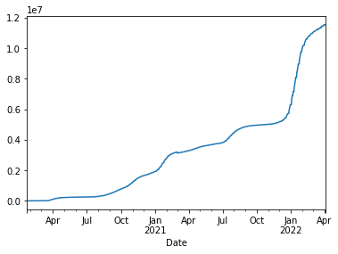

```python
df_es.set_index('Date')['Cases'].plot()
```

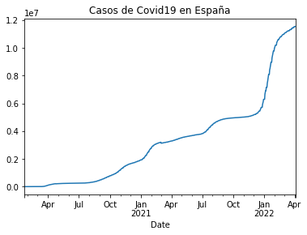

```python
df_es.set_index('Date')['Cases'].plot(title="Casos de Covid19 en España")
```

## Tiempo real Colombia

Haremos lo mismo con colombia pero en lugar de es, en el dataframe y la URL pondremos Colombia para que lea y reproduzca los datos de este país

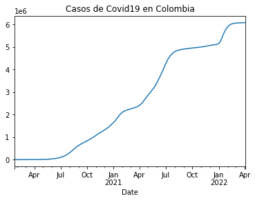

```python
url_co = 'https://api.covid19api.com/country/colombia/status/confirmed/live'
df_co = pd.read_json(url_co)
df_co.set_index('Date')['Cases'].plot(title="Casos de Covid19 en Colombia")
```

## Comparativa España - Colombia

Una vez obtenidos todos los datos, haremos una cmparación entre ambos. Para ello concatenaremos los datos de ambos países del eje 1 y los visualizaremos tanto en formato tabla (casos y fecha) como en formato gráfico, para ver el aumento de caos de covid 19 en ambos países.

```python
casos_es = df_es.set_index('Date')['Cases']
casos_co = df_co.set_index('Date')['Cases']
```

```python
pd.concat([casos_es,casos_co],axis=1)
```

| Date | Cases | Cases |
| --- | --- | --- |
| 2020-01-22 00:00:00+00:00 | 0 | 0 |
| 2020-01-23 00:00:00+00:00 | 0 | 0 |
| 2020-01-24 00:00:00+00:00 | 0 | 0 |
| 2020-01-25 00:00:00+00:00 | 0 | 0 |
| 2020-01-26 00:00:00+00:00 | 0 | 0 |
| ... | ... | ... |
| 2022-03-31 00:00:00+00:00 | 11508309 | 6084916 |
| 2022-04-01 00:00:00+00:00 | 11551574 | 6085270 |
| 2022-04-02 00:00:00+00:00 | 11551574 | 6085618 |
| 2022-04-03 00:00:00+00:00 | 11551574 | 6085926 |
| 2022-04-04 00:00:00+00:00 | 11551574 | 6086233 |

804 rows × 2 columns

```python
vs = pd.concat([casos_es,casos_co],axis=1)
vs
```

| Date | Cases | Cases |
| --- | --- | --- |
| 2020-01-22 00:00:00+00:00 | 0 | 0 |
| 2020-01-23 00:00:00+00:00 | 0 | 0 |
| 2020-01-24 00:00:00+00:00 | 0 | 0 |
| 2020-01-25 00:00:00+00:00 | 0 | 0 |
| 2020-01-26 00:00:00+00:00 | 0 | 0 |
| ... | ... | ... |
| 2022-03-31 00:00:00+00:00 | 11508309 | 6084916 |
| 2022-04-01 00:00:00+00:00 | 11551574 | 6085270 |
| 2022-04-02 00:00:00+00:00 | 11551574 | 6085618 |
| 2022-04-03 00:00:00+00:00 | 11551574 | 6085926 |
| 2022-04-04 00:00:00+00:00 | 11551574 | 6086233 |

804 rows × 2 columns

```python
vs.columns = ['España', 'Colombia']
vs
```

| Date | España | Colombia |
| --- | --- | --- |
| 2020-01-22 00:00:00+00:00 | 0 | 0 |
| 2020-01-23 00:00:00+00:00 | 0 | 0 |
| 2020-01-24 00:00:00+00:00 | 0 | 0 |
| 2020-01-25 00:00:00+00:00 | 0 | 0 |
| 2020-01-26 00:00:00+00:00 | 0 | 0 |
| ... | ... | ... |
| 2022-03-31 00:00:00+00:00 | 11508309 | 6084916 |
| 2022-04-01 00:00:00+00:00 | 11551574 | 6085270 |
| 2022-04-02 00:00:00+00:00 | 11551574 | 6085618 |
| 2022-04-03 00:00:00+00:00 | 11551574 | 6085926 |
| 2022-04-04 00:00:00+00:00 | 11551574 | 6086233 |

804 rows × 2 columns

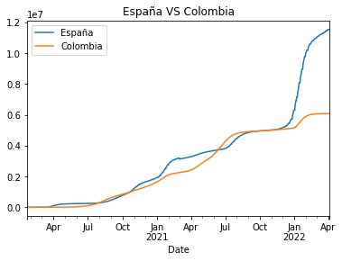

```python
vs.plot(title="España VS Colombia")
```

## Triple Comparativa

Por último, y de la misma manera que hicimos con España y Colombia, añadiremos una tercera variable: Portugal. La exttracción de datos se realiza de manera idéntica a través de la URL matizando los datos de Portugal y concatenandolos para ver los resultados en una tabla y posteriormente en un gráfica para poder compararlos de una manera más sencilla.

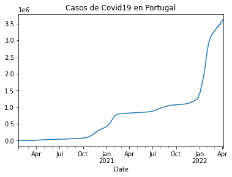

```python
url_pt = 'https://api.covid19api.com/country/portugal/status/confirmed/live'
df_pt = pd.read_json(url_pt)
df_pt.set_index('Date')['Cases'].plot(title="Casos de Covid19 en Portugal")
```

```python
casos_es = df_es.set_index('Date')['Cases']
casos_co = df_co.set_index('Date')['Cases']
casos_pt = df_pt.set_index('Date')['Cases']
```

```python
pd.concat([casos_es,casos_co,casos_pt],axis=1)
```

| Date | Cases | Cases | Cases |
| --- | --- | --- | --- |
| 2020-01-22 00:00:00+00:00 | 0.0 | 0.0 | 0 |
| 2020-01-23 00:00:00+00:00 | 0.0 | 0.0 | 0 |
| 2020-01-24 00:00:00+00:00 | 0.0 | 0.0 | 0 |
| 2020-01-25 00:00:00+00:00 | 0.0 | 0.0 | 0 |
| 2020-01-26 00:00:00+00:00 | 0.0 | 0.0 | 0 |
| ... | ... | ... | ... |
| 2022-04-01 00:00:00+00:00 | 11551574.0 | 6085270.0 | 3604114 |
| 2022-04-02 00:00:00+00:00 | 11551574.0 | 6085618.0 | 3604114 |
| 2022-04-03 00:00:00+00:00 | 11551574.0 | 6085926.0 | 3604114 |
| 2022-04-04 00:00:00+00:00 | 11551574.0 | 6086233.0 | 3609846 |
| 2022-04-05 00:00:00+00:00 | NaN | NaN | 3609846 |

805 rows × 3 columns

```python
vs = pd.concat([casos_es,casos_co,casos_pt],axis=1)
vs
```

| Date | Cases | Cases | Cases |
| --- | --- | --- | --- |
| 2020-01-22 00:00:00+00:00 | 0.0 | 0.0 | 0 |
| 2020-01-23 00:00:00+00:00 | 0.0 | 0.0 | 0 |
| 2020-01-24 00:00:00+00:00 | 0.0 | 0.0 | 0 |
| 2020-01-25 00:00:00+00:00 | 0.0 | 0.0 | 0 |
| 2020-01-26 00:00:00+00:00 | 0.0 | 0.0 | 0 |
| ... | ... | ... | ... |
| 2022-04-01 00:00:00+00:00 | 11551574.0 | 6085270.0 | 3604114 |
| 2022-04-02 00:00:00+00:00 | 11551574.0 | 6085618.0 | 3604114 |
| 2022-04-03 00:00:00+00:00 | 11551574.0 | 6085926.0 | 3604114 |
| 2022-04-04 00:00:00+00:00 | 11551574.0 | 6086233.0 | 3609846 |
| 2022-04-05 00:00:00+00:00 | NaN | NaN | 3609846 |

805 rows × 3 columns

```python
vs.columns = ['España', 'Colombia', 'Portugal']
vs
```

| Date | España | Colombia | Portugal |
| --- | --- | --- | --- |
| 2020-01-22 00:00:00+00:00 | 0.0 | 0.0 | 0 |
| 2020-01-23 00:00:00+00:00 | 0.0 | 0.0 | 0 |
| 2020-01-24 00:00:00+00:00 | 0.0 | 0.0 | 0 |
| 2020-01-25 00:00:00+00:00 | 0.0 | 0.0 | 0 |
| 2020-01-26 00:00:00+00:00 | 0.0 | 0.0 | 0 |
| ... | ... | ... | ... |
| 2022-04-01 00:00:00+00:00 | 11551574.0 | 6085270.0 | 3604114 |
| 2022-04-02 00:00:00+00:00 | 11551574.0 | 6085618.0 | 3604114 |
| 2022-04-03 00:00:00+00:00 | 11551574.0 | 6085926.0 | 3604114 |
| 2022-04-04 00:00:00+00:00 | 11551574.0 | 6086233.0 | 3609846 |
| 2022-04-05 00:00:00+00:00 | NaN | NaN | 3609846 |

805 rows × 3 columns

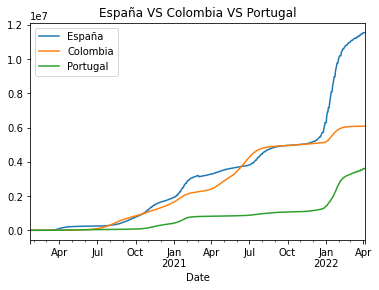

```python
vs.plot(title="España VS Colombia VS Portugal")
```

## Exportar datos

Como paso final exportaremos los datos a excel .

```python
vs.to_csv('vs.csv')
```

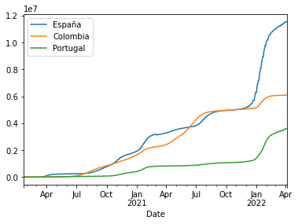

```python
grafico = vs.plot()
fig = grafico.get_figure()
fig.savefig("vs.png")
```

# COMETARIO GRÁFICA TRIPLE

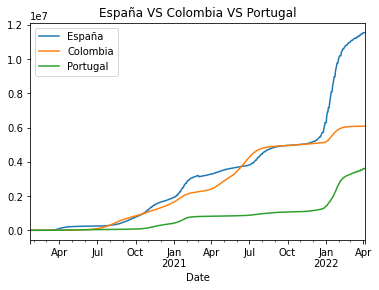

```python
vs.plot(title="España VS Colombia VS Portugal")
```

Procedemos a cometar la tríple gráfica. Los países seleccionados han sido **España** (azul), **Colombia** (naranja), y **Portugal** (verde). Estudiamos el aumento de los casos del covid-19 en estos tres lugares.

**El país con mayor aumento de casos de covid es , con diferencia, España**. Podemos ver como ha ido aumentando gradualmente, con algunas fluctuaciones hasta que, cuando parecia que se mantenían, los casos se dispararon notablemente.

**Colombia se encuentra en el medio de ambos**: sus caos comenzaron aumentando rapidamente, después se estavilizaron, sufrieron un pequeño aumento y volvieron a estabilizarse, con una cifra considerable de casos.

**El país que menos ha sufrido los efectos del covid es Portugal**. Sus casos prácticamente siempre se han mantenido estable, con un mínimo aumento hasta recuperar la estabilidad y finalmente retomar una subida en el último momento, aunque nada parecia a España, a pesar de su proximidad con España.